# Informe Seguimiento del Logro Encla 2023

En el siguiente informe se presenta un resumen del sistema de seguimiento al logro, dividido en dos grandes partes: resumen nacional y regional. El informe consiste en una presentación de las tasas de logro de las unidades económicas. Es decir, el informe hace referencia a la cantidad de empresas que han sido encuestadas divididas por la muestra objetivo, que corresponde a 4.267 unidades económicas.

El estado de logro se calcula con la siguiente fórmula:
$$\frac{U_{El}}{N_{obj}}*100$$

Donde el valor de $U_{El}$ es el n de las unidades económicas logradas; el valor de $N_{obj}$ corresponde a la muestra objetivo a encuestar.

La variable que se utilizó para medir el Estado de logro, es precisamente esta, que consta de 4 categorías de respuesta. Estas son: a) “Logro total”, que indica cuando las unidades económicas responden el cuestionario de empleadores, trabajores/sindicatos y el cuestionario autoaplicado; b) “Logro parcial”, que indica cuando las unidades económicas responden el cuestionario autoaplicado y el cuestionario de empleadores o trabajadores/sindicatos; c) “Logro parcial (sin AA)”, que indica los cuestionarios empleadores y trabajores/sindicatos completos con excepción del cuestionario autoaplicado; y d) “Sin logro”, que indica cuando no hay cuestionarios respondidos en esa unidad.

Para que un cuestionario se considere “Logrado” se necesita el cumplimiento de estos 3 criterios: a) es completado por recolector/a; b) es revisado por equipo técnico y evaluado según criterios de suficiencia; c) en caso de ser necesario, es corregido y/o completado una vez recontactando al informante.

# Resumen nacional

## Logro global

**N°**

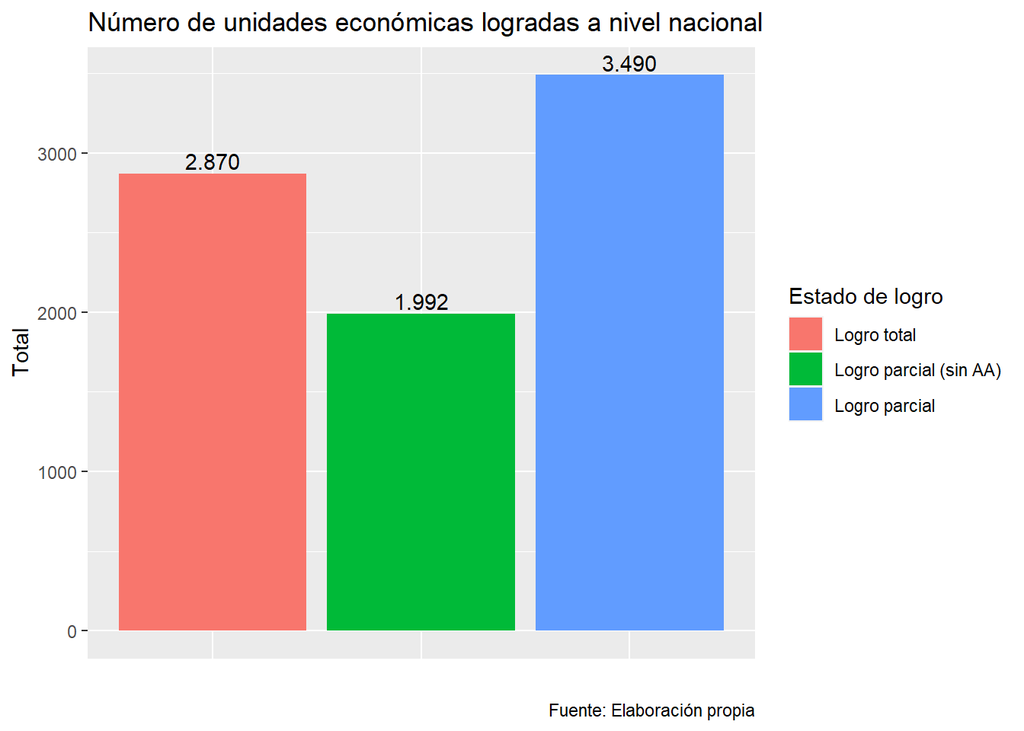

**%**

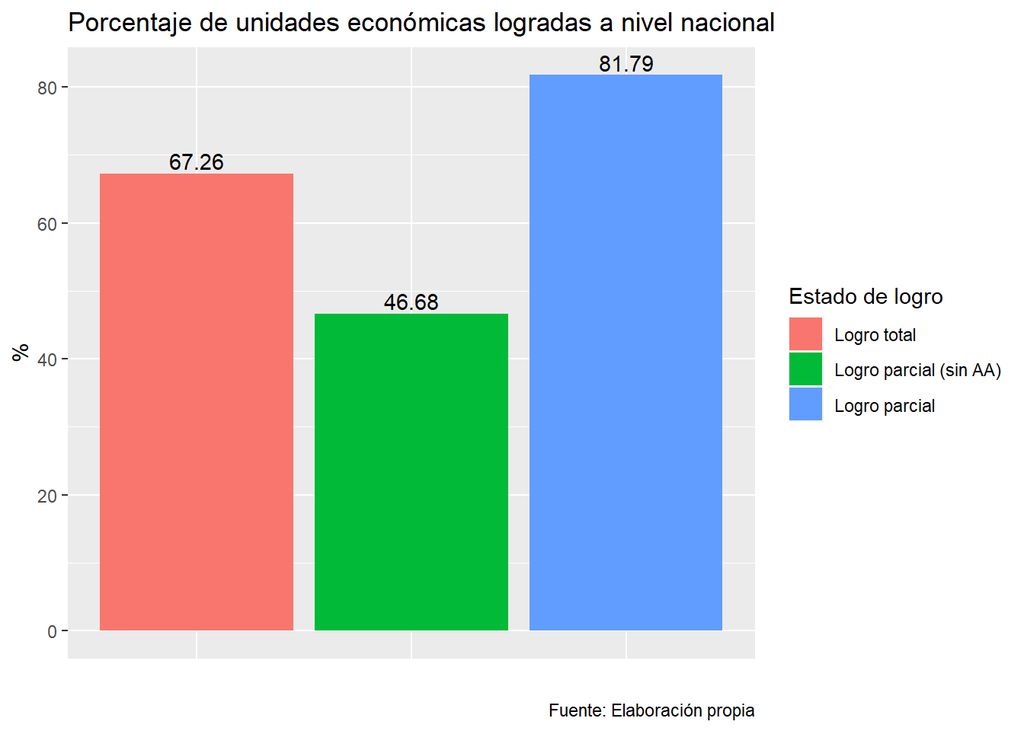

## Logro por tamaño

**N°**

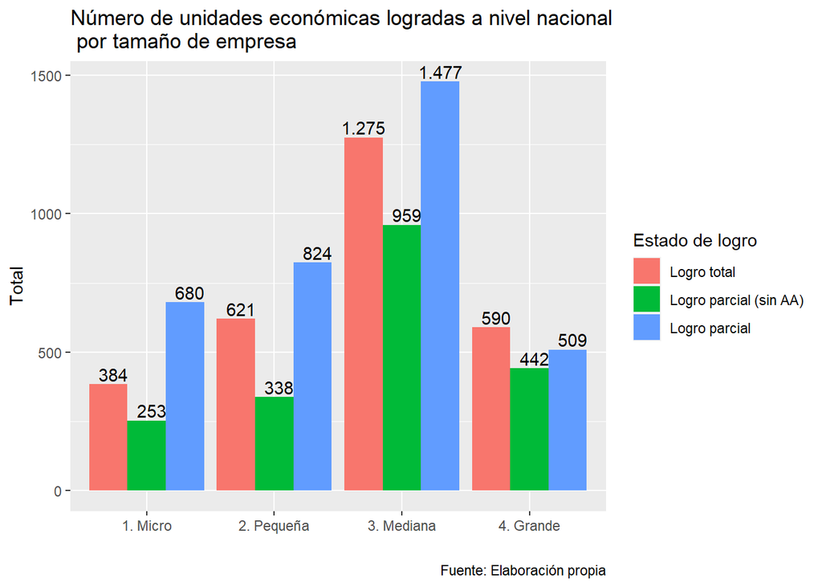

**%**

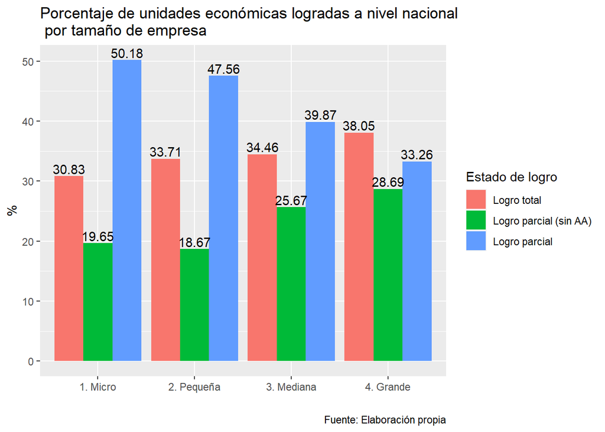

## Logro por actividad económica

**N°**

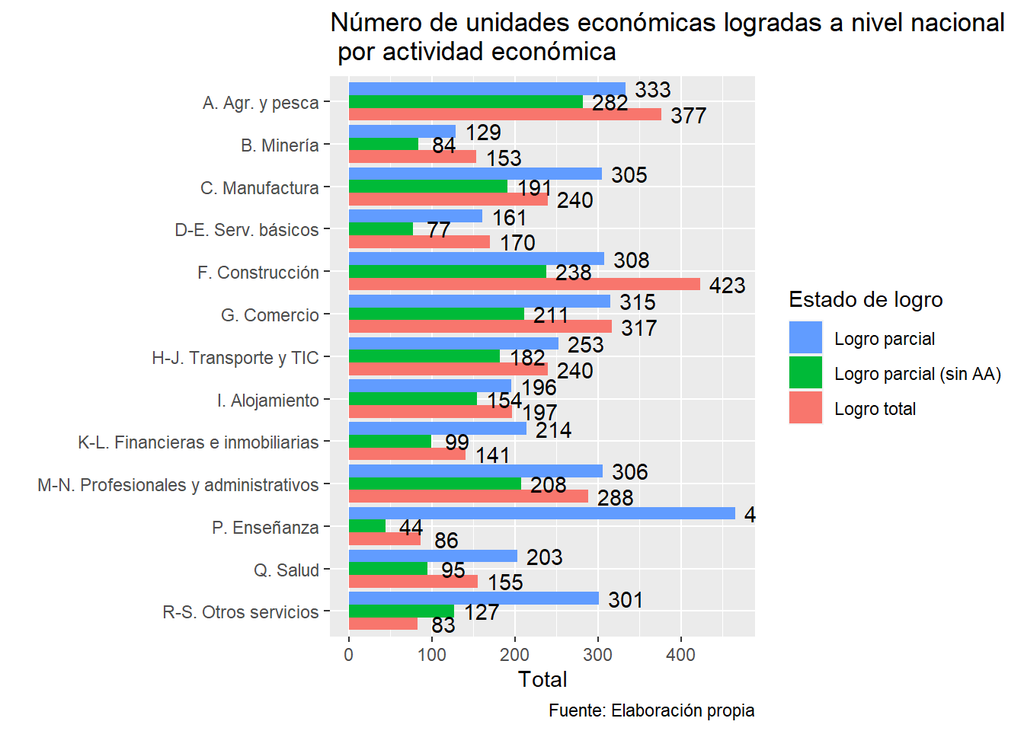

**%**

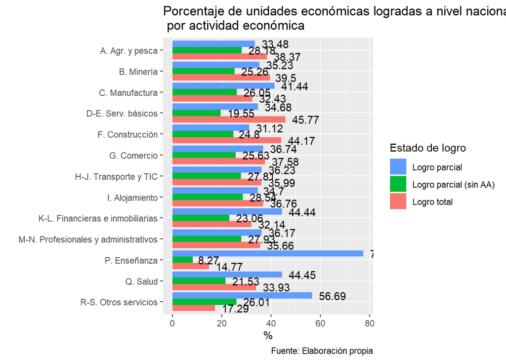

## Logro por región

**N°**

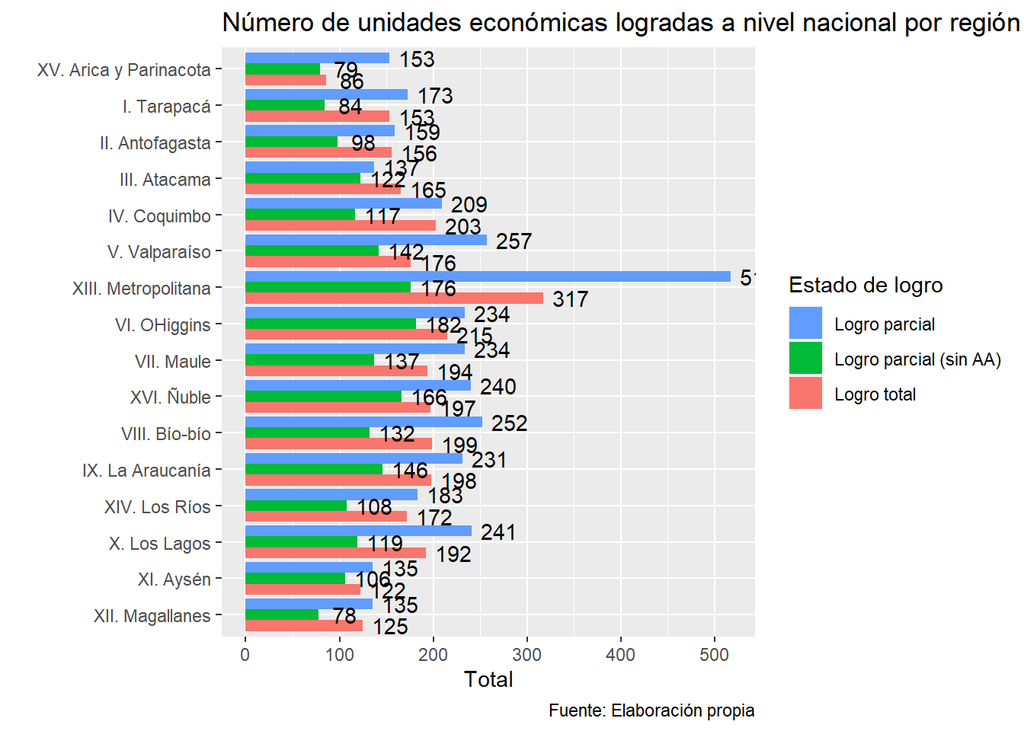

**%**

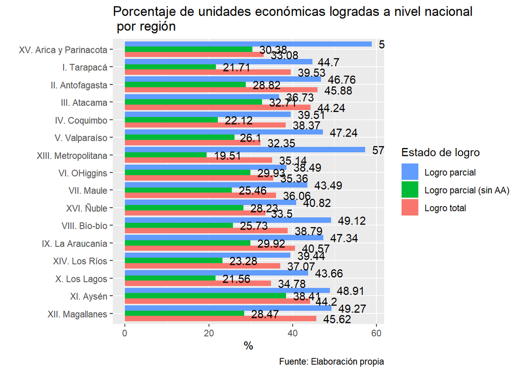

# Resumen regional

A continuación se presenta el estado de logro de las unidades económicas por región

## Región XV. Arica y Parinacota

### Global región

**N°**

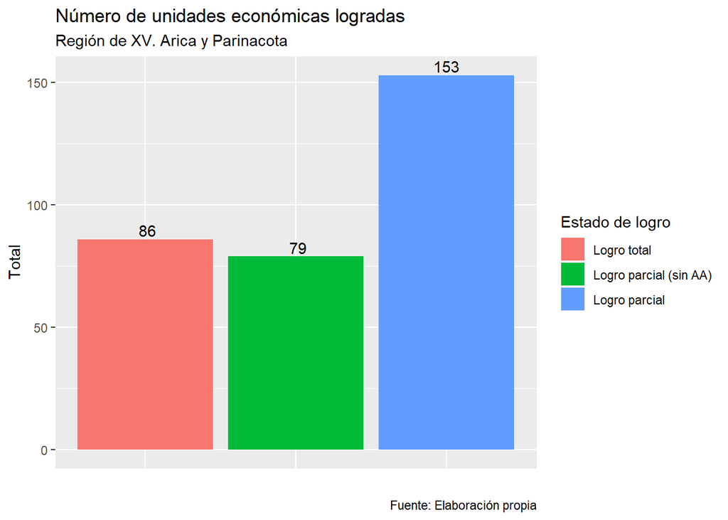

**%**

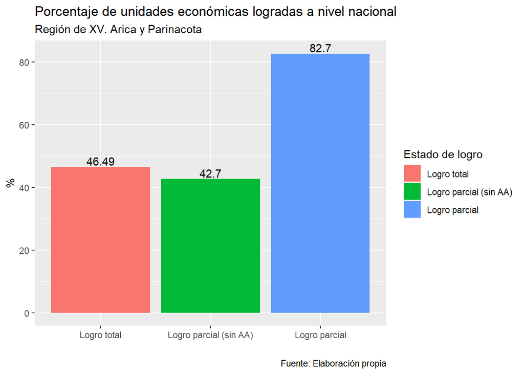

### Logro por tamaño

**N°**

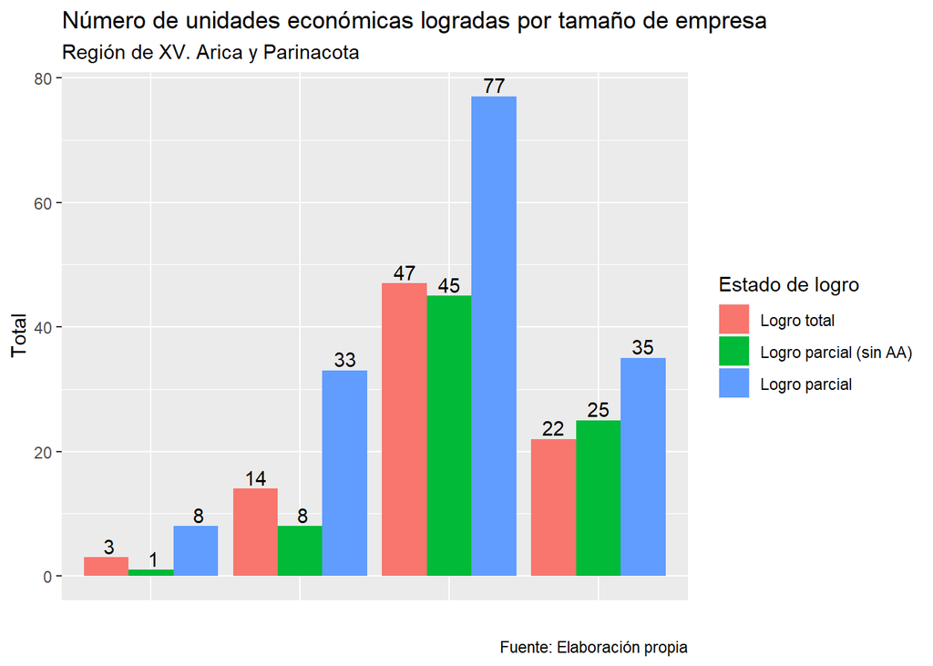

**%**

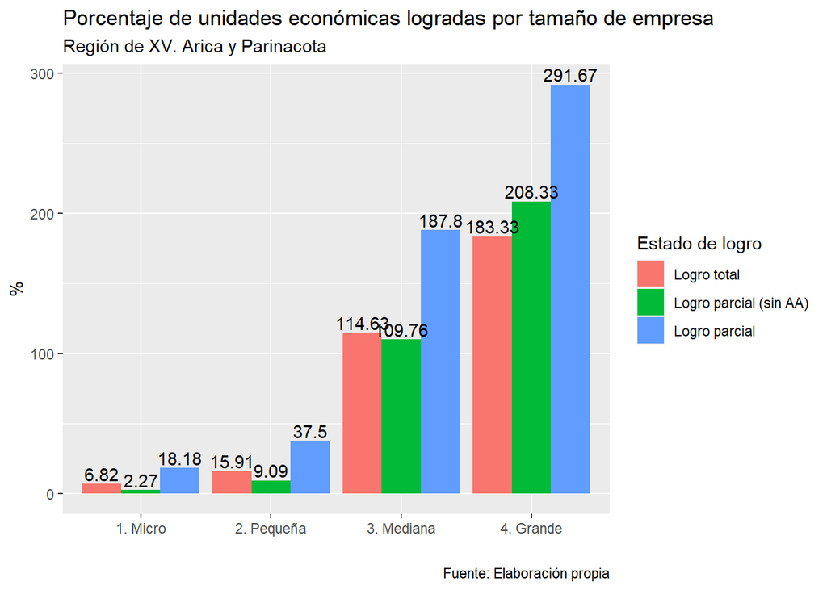

## Región I. Tarapacá

### Global región

**N°**

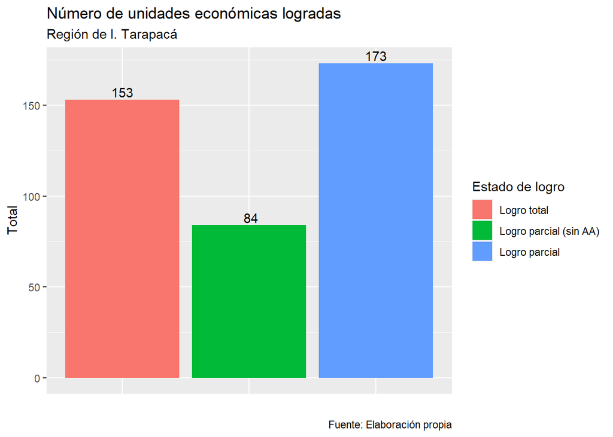

**%**

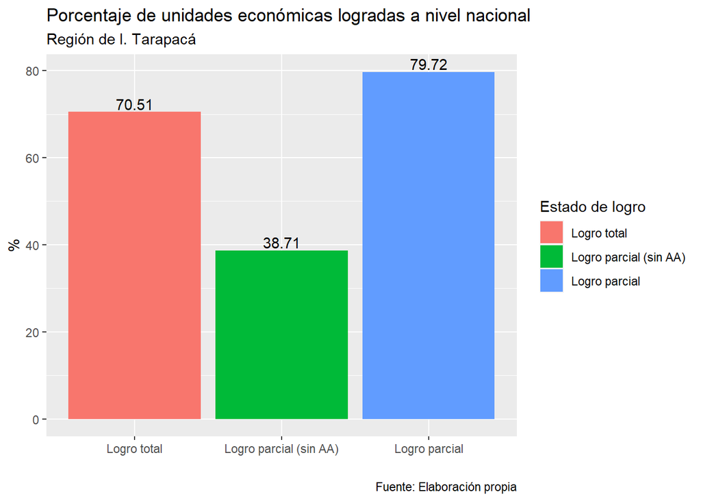

### Logro por tamaño

**N°**

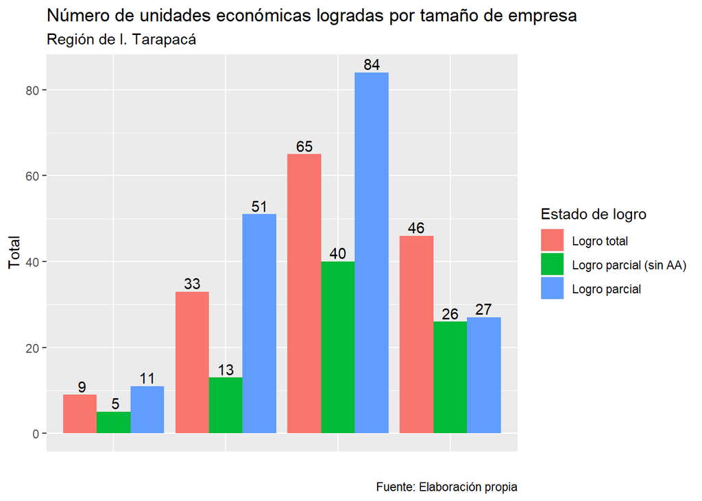

**%**

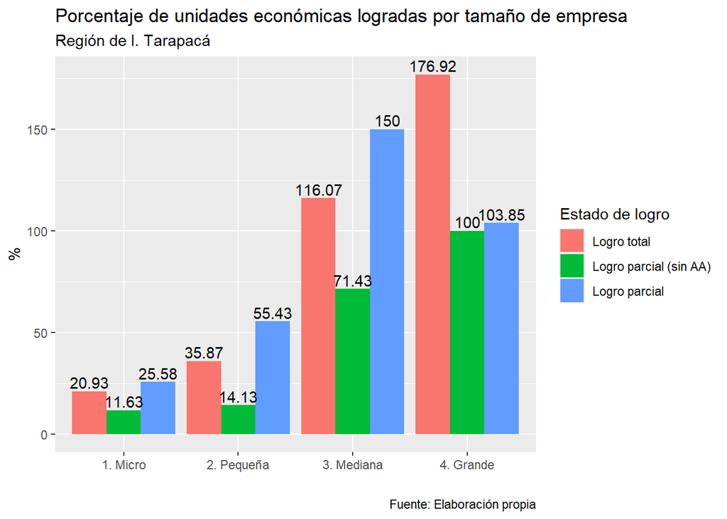

## Región II. Antofagasta

### Global región

**N°**

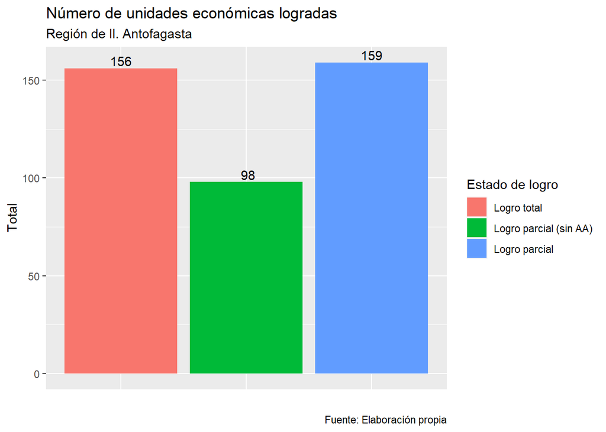

**%**

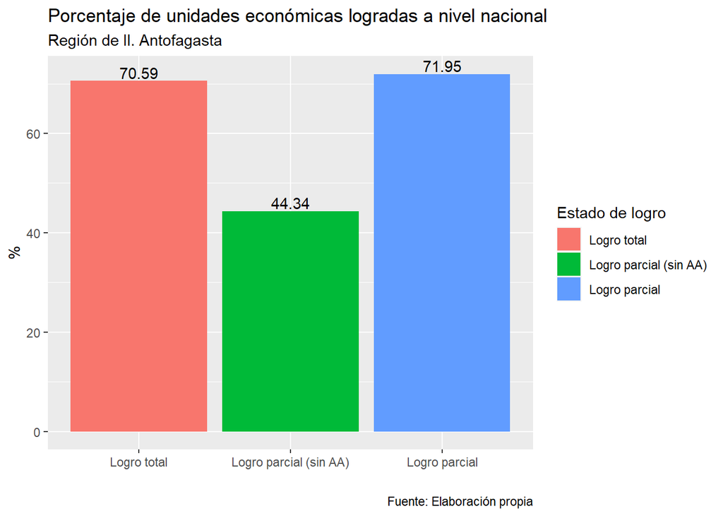

### Logro por tamaño

**N°**

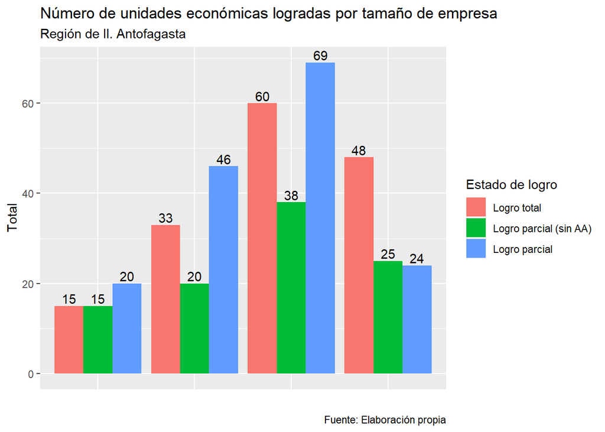

**%**

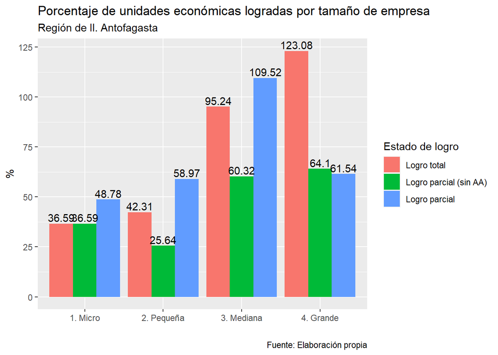

## Región III. Atacama

### Global región

**N°**

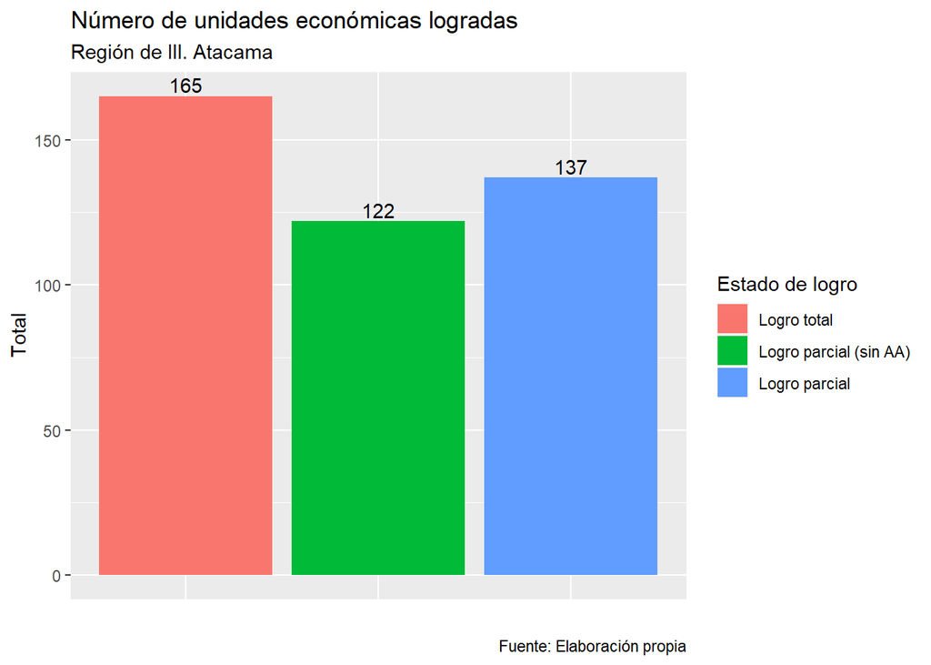

**%**

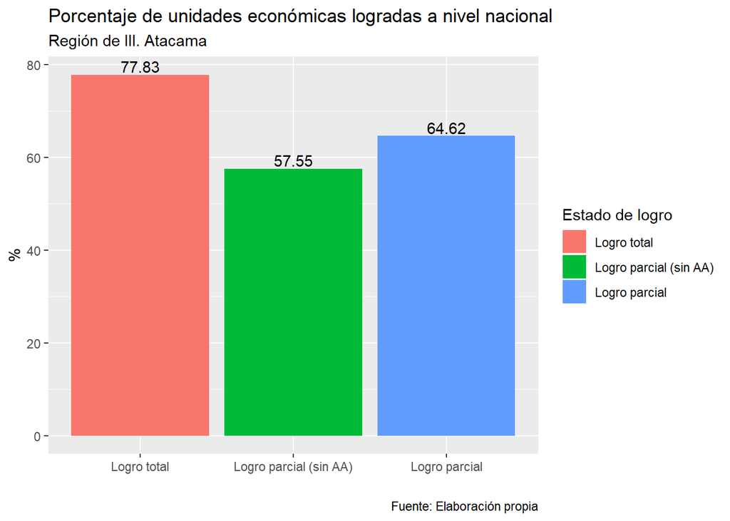

### Logro por tamaño

**N°**

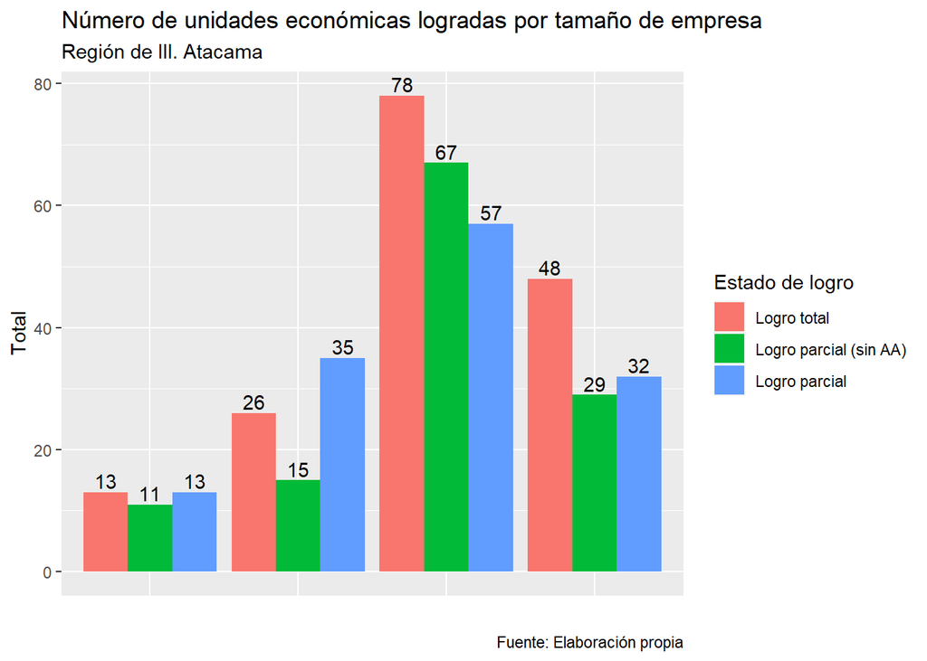

**%**

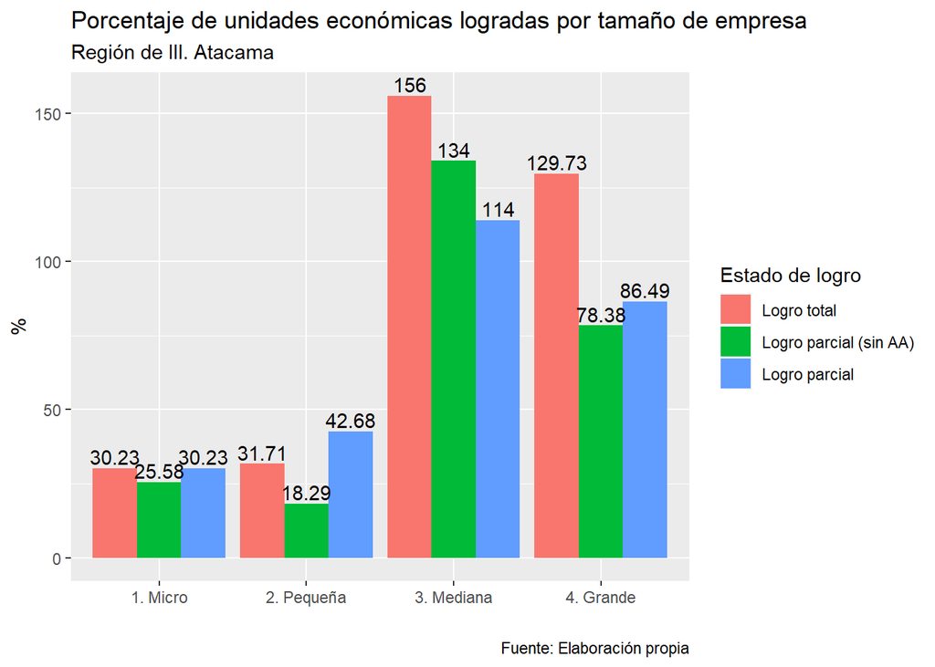

## Región IV. Coquimbo

### Global región

**N°**

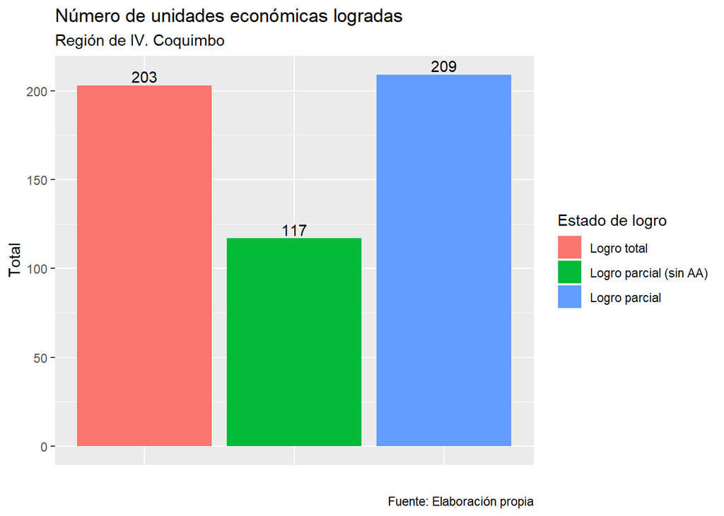

**%**

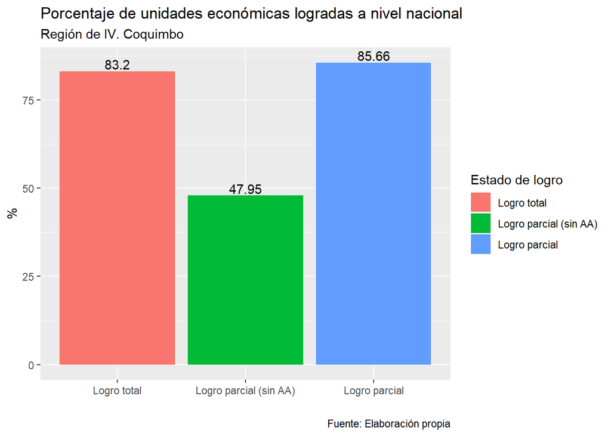

### Logro por tamaño

**N°**

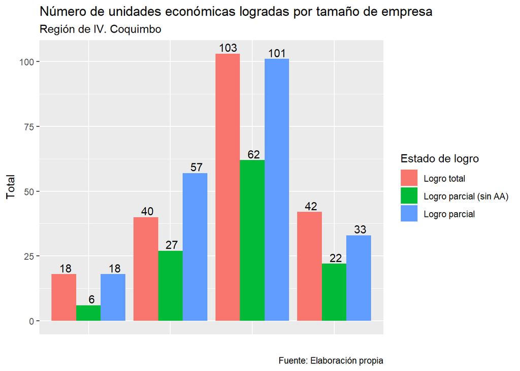

**%**

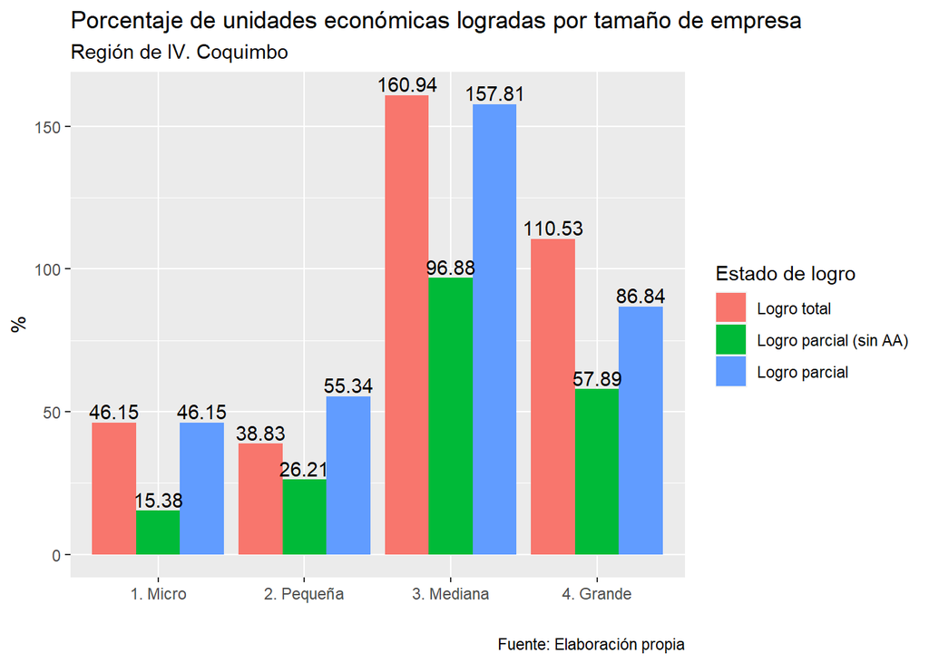

## Región V. Valparaíso

### Global región

**N°**

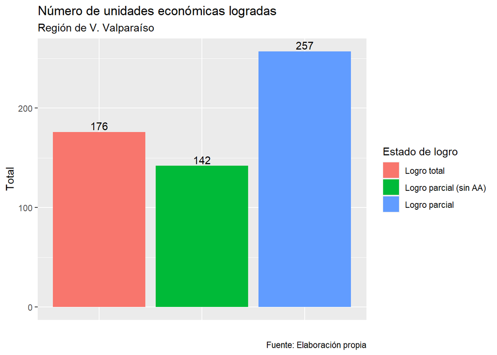

**%**

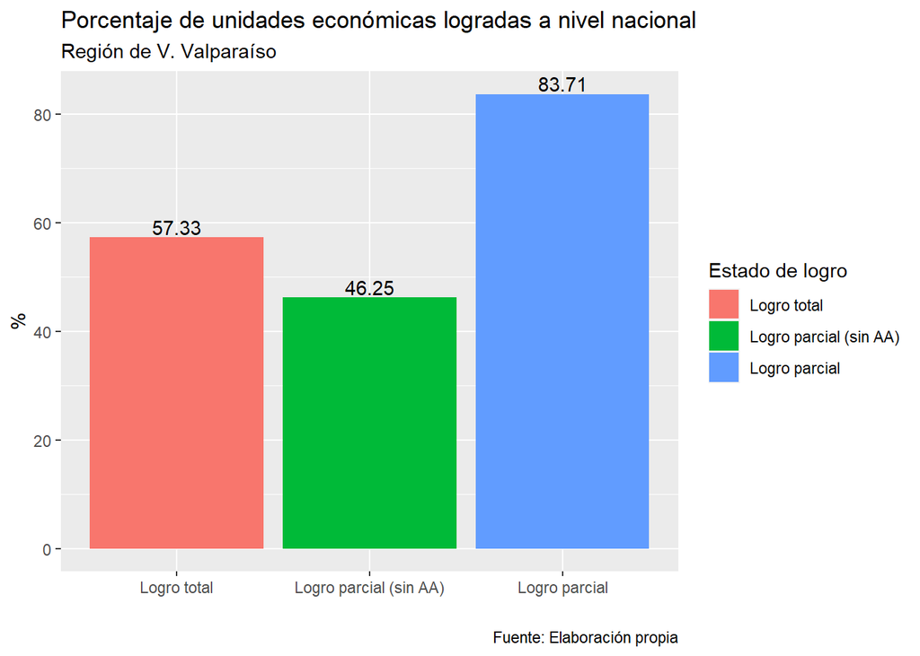

### Logro por tamaño

**N°**

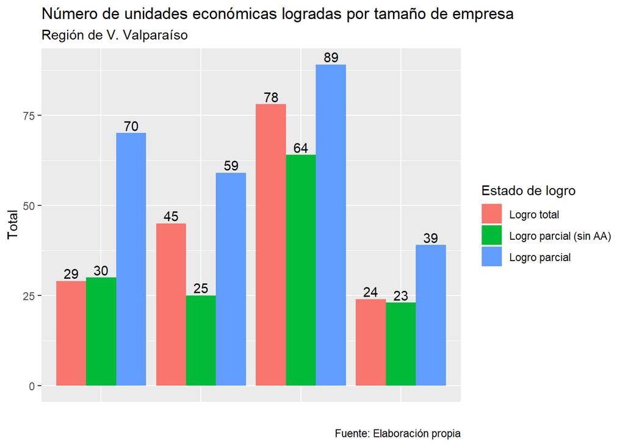

**%**

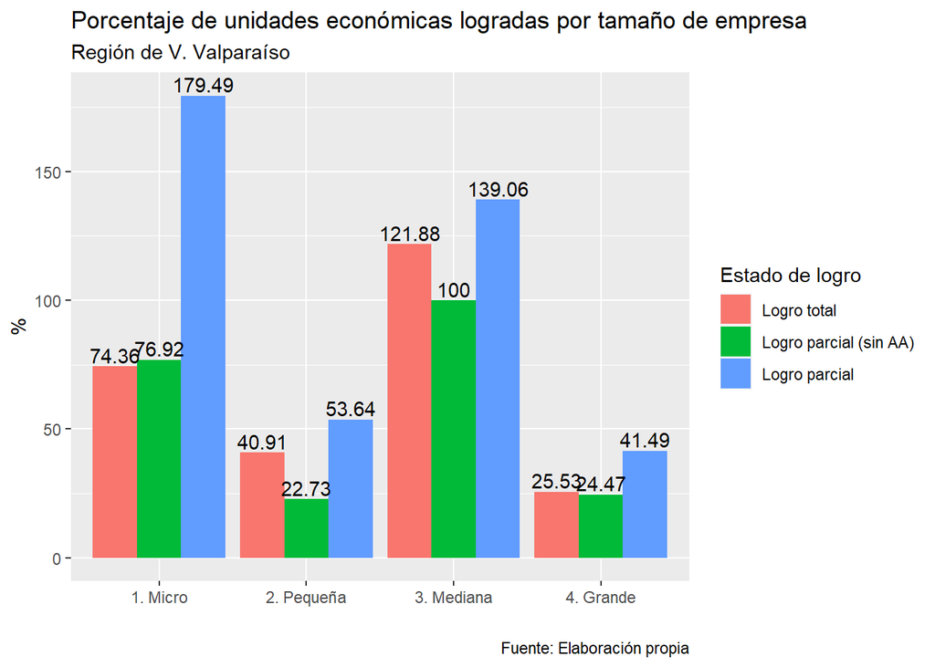